# Introduction to Julia

### 9.2 Indexing

```julia
# 5 × 5 matrix of random Normal(0, 1)
x = randn(5, 5)
```

```
5×5 Matrix{Float64}:
 -1.00829    1.42918   -0.876112   0.674993   0.340248
 -0.493246   0.193201   0.431973  -0.114723  -0.525402
  0.911637  -0.411778   1.52413    0.62592    0.585986
  1.33735    0.9701     0.686554  -0.532545   0.933378
 -1.45963   -0.234725  -0.560424  -0.325453  -1.1651
```

```julia
# first column
x[:, 1]
```

```
5-element Vector{Float64}:
 -1.0082878642628228
 -0.49324649347079297
  0.9116368000184132
  1.3373534865879368
 -1.4596334132489657
```

```julia
# first row
x[1, :]
```

```
5-element Vector{Float64}:
 -1.0082878642628228
  1.4291812336443466
 -0.8761116073704214
  0.6749926102770285
  0.34024791924568143
```

```julia
# sub-array
x[1:2, 2:3]
```

```
2×2 Matrix{Float64}:
 1.42918   -0.876112
 0.193201   0.431973
```

```julia
# getting a subset of a matrix creates a copy, but you can also create "views"
z = view(x, 1:2, 2:3)
```

```
2×2 view(::Matrix{Float64}, 1:2, 2:3) with eltype Float64:
 1.42918   -0.876112
 0.193201   0.431973
```

```julia
# same as
@views z = x[1:2, 2:3]
```

```
2×2 view(::Matrix{Float64}, 1:2, 2:3) with eltype Float64:
 1.42918   -0.876112
 0.193201   0.431973
```

```julia
# change in z (view) changes x as well
z[2, 2] = 0.0
x
```

```
5×5 Matrix{Float64}:
 -1.00829    1.42918   -0.876112   0.674993   0.340248
 -0.493246   0.193201   0.0       -0.114723  -0.525402
  0.911637  -0.411778   1.52413    0.62592    0.585986
  1.33735    0.9701     0.686554  -0.532545   0.933378
 -1.45963   -0.234725  -0.560424  -0.325453  -1.1651
```

```julia
# y points to same data as x
y = x
```

```
5×5 Matrix{Float64}:
 -1.00829    1.42918   -0.876112   0.674993   0.340248
 -0.493246   0.193201   0.0       -0.114723  -0.525402
  0.911637  -0.411778   1.52413    0.62592    0.585986
  1.33735    0.9701     0.686554  -0.532545   0.933378
 -1.45963   -0.234725  -0.560424  -0.325453  -1.1651
```

```julia
# x and y point to same data
pointer(x), pointer(y)
```

```
(Ptr{Float64} @0x000000031c8c5de0, Ptr{Float64} @0x000000031c8c5de0)
```

```julia
# changing y also changes x
y[:, 1] .= 0
x
```

```
5×5 Matrix{Float64}:
 0.0   1.42918   -0.876112   0.674993   0.340248
 0.0   0.193201   0.0       -0.114723  -0.525402
 0.0  -0.411778   1.52413    0.62592    0.585986
 0.0   0.9701     0.686554  -0.532545   0.933378
 0.0  -0.234725  -0.560424  -0.325453  -1.1651
```

```julia
# create a new copy of data
z = copy(x)
```

```
5×5 Matrix{Float64}:
 0.0   1.42918   -0.876112   0.674993   0.340248
 0.0   0.193201   0.0       -0.114723  -0.525402
 0.0  -0.411778   1.52413    0.62592    0.585986
 0.0   0.9701     0.686554  -0.532545   0.933378
 0.0  -0.234725  -0.560424  -0.325453  -1.1651
```

```julia
pointer(x), pointer(z)
```

```
(Ptr{Float64} @0x000000031c8c5de0, Ptr{Float64} @0x000000031becaf60)
```

### 9.3 Concatenate matrices

```julia
# 3-by-1 vector
[1, 2, 3]
```

```
3-element Vector{Int64}:
 1
 2
 3
```

```julia
# 1-by-3 array
[1 2 3]
```

```
1×3 Matrix{Int64}:
 1  2  3
```

```julia
# multiple assignment by tuple
x, y, z = randn(5, 3), randn(5, 2), randn(3, 5)
```

```
([0.2242823393836569 -1.7138037049828658 -0.036978353294990864; -0.4413949532639589 0.19195322892694416 -1.26362181131408; … ; 0.5386623597183907 1.4594883102361922 -0.7917189369857376; 2.0525393640088603 0.6183464993115776 0.7408534886159363], [-0.9284152329267081 -1.456052990204398; -0.42934597094…
```

```julia
[x y] # 5-by-5 matrix
```

```
5×5 Matrix{Float64}:
  0.224282  -1.7138    -0.0369784  -0.928415  -1.45605
 -0.441395   0.191953  -1.26362    -0.429346  -0.693533
 -0.108974  -1.79743   -0.968297    0.204003   0.535644
  0.538662   1.45949   -0.791719   -1.21461    0.513561
  2.05254    0.618346   0.740853    2.0298     0.789225
```

```julia
[x y; z] # 8-by-5 matrix
```

```
8×5 Matrix{Float64}:
  0.224282  -1.7138    -0.0369784  -0.928415  -1.45605
 -0.441395   0.191953  -1.26362    -0.429346  -0.693533
 -0.108974  -1.79743   -0.968297    0.204003   0.535644
  0.538662   1.45949   -0.791719   -1.21461    0.513561
  2.05254    0.618346   0.740853    2.0298     0.789225
 -0.814322   0.169454   1.42224    -1.51846   -1.6207
 -0.862319   0.341736   0.46134    -0.566405  -0.400213
 -0.167746  -0.085684  -1.85986     0.271889  -0.732606
```

### 9.4 Dot operation (broadcasting)

Dot operation in Julia is elementwise operation, similar to Matlab.

```julia
x = randn(5, 3)
```

```
5×3 Matrix{Float64}:
  0.076522  -0.917166   -0.200622
 -0.88522   -0.976642   -0.669177
 -1.5188     0.0918114  -1.50438
  2.64529    0.790842   -1.28675
  0.793202   1.03624    -0.235334
```

```julia
y = ones(5, 3)
```

```
5×3 Matrix{Float64}:
 1.0  1.0  1.0
 1.0  1.0  1.0
 1.0  1.0  1.0
 1.0  1.0  1.0
 1.0  1.0  1.0
```

```julia
x .* y # same x * y in R
```

```
5×3 Matrix{Float64}:
  0.076522  -0.917166   -0.200622
 -0.88522   -0.976642   -0.669177
 -1.5188     0.0918114  -1.50438
  2.64529    0.790842   -1.28675
  0.793202   1.03624    -0.235334
```

```julia
x .^ (-2)
```

```
5×3 Matrix{Float64}:
 170.776       1.18879   24.8451
   1.27614     1.0484     2.23315
   0.433508  118.633      0.441863
   0.142906    1.5989     0.603964
   1.5894      0.931281  18.0564
```

```julia
sin.(x)
```

```
5×3 Matrix{Float64}:
  0.0764473  -0.793881   -0.199279
 -0.774054   -0.828622   -0.62034
 -0.998649    0.0916825  -0.997795
  0.476174    0.710946   -0.95993
  0.712603    0.860494   -0.233168
```

### 9.5 Basic linear algebra

```julia
x = randn(5)
```

```
5-element Vector{Float64}:
 -0.6160722689186728
 -0.7124082391722473
 -0.12500327594792363
  0.4206430367448013
 -0.30667277300118306
```

```julia
# vector L2 norm
norm(x)
```

```
1.0833674874348682
```

```julia
# same as
sqrt(sum(abs2, x))
```

```
1.0833674874348682
```

```julia
y = randn(5) # another vector
# dot product
dot(x, y) # x' * y
```

```
1.0290691640435927
```

```julia
# same as
x'y
```

```
1.0290691640435927
```

```julia
x, y = randn(5, 3), randn(3, 2)
# matrix multiplication, same as %*% in R
x * y
```

```
5×2 Matrix{Float64}:
  1.37573   -1.70603
  0.25978   -0.0327548
 -1.32104    0.95593
  0.597036   0.564457
 -1.80454   -0.259589
```

```julia
x = randn(3, 3)
```

```
3×3 Matrix{Float64}:
 2.17345    0.436274  -0.114771
 1.85661    0.968813   0.42073
 0.187513  -1.30033   -1.374
```

```julia
# conjugate transpose
x'
```

```
3×3 adjoint(::Matrix{Float64}) with eltype Float64:
  2.17345   1.85661    0.187513
  0.436274  0.968813  -1.30033
 -0.114771  0.42073   -1.374
```

```julia
b = rand(3)
x'b # same as x' * b
```

```
3-element Vector{Float64}:
  2.027465166143618
 -0.4784022660861423
 -1.0218808683840002
```

```julia
# trace
tr(x)
```

```
1.7682692018500024
```

```julia
det(x)
```

```
-0.258841686498328
```

```julia
rank(x)
```

```
3
```

### 9.6 Sparse matrices

```julia
# 10-by-10 sparse matrix with sparsity 0.1
X = sprandn(10, 10, .1)
```

```
10×10 SparseMatrixCSC{Float64, Int64} with 7 stored entries:
  ⋅          ⋅         ⋅     ⋅        …   ⋅     ⋅        ⋅    ⋅
 0.603112    ⋅         ⋅     ⋅            ⋅   -1.82107   ⋅    ⋅
  ⋅        -0.372368   ⋅     ⋅            ⋅     ⋅        ⋅    ⋅
  ⋅          ⋅         ⋅     ⋅            ⋅     ⋅        ⋅    ⋅
  ⋅          ⋅         ⋅     ⋅            ⋅     ⋅        ⋅    ⋅
  ⋅          ⋅         ⋅   -0.345201  …   ⋅     ⋅        ⋅    ⋅
  ⋅          ⋅         ⋅     ⋅            ⋅     ⋅        ⋅    ⋅
  ⋅          ⋅         ⋅     ⋅            ⋅     ⋅        ⋅    ⋅
  ⋅          ⋅         ⋅     ⋅            ⋅     ⋅        ⋅    ⋅
  ⋅          ⋅         ⋅     ⋅            ⋅     ⋅        ⋅   0.685263
```

```julia
# dump() in Julia is like str() in R
dump(X)
```

```
SparseMatrixCSC{Float64, Int64}
  m: Int64 10
  n: Int64 10
  colptr: Array{Int64}((11,)) [1, 2, 3, 3, 4, 5, 6, 6, 7, 7, 8]
  rowval: Array{Int64}((7,)) [2, 3, 6, 2, 7, 2, 10]
  nzval: Array{Float64}((7,)) [0.6031118284436581, -0.37236769835979655, -0.3452007407460549, 0.43453625457595846, -1.6918818826031499, -1.8210705359052912, 0.685263323700436]
```

```julia
# convert to dense matrix; be cautious when dealing with big data
Xfull = convert(Matrix{Float64}, X)
```

```
10×10 Matrix{Float64}:
 0.0        0.0       0.0   0.0       …  0.0   0.0      0.0  0.0
 0.603112   0.0       0.0   0.0          0.0  -1.82107  0.0  0.0
 0.0       -0.372368  0.0   0.0          0.0   0.0      0.0  0.0
 0.0        0.0       0.0   0.0          0.0   0.0      0.0  0.0
 0.0        0.0       0.0   0.0          0.0   0.0      0.0  0.0
 0.0        0.0       0.0  -0.345201  …  0.0   0.0      0.0  0.0
 0.0        0.0       0.0   0.0          0.0   0.0      0.0  0.0
 0.0        0.0       0.0   0.0          0.0   0.0      0.0  0.0
 0.0        0.0       0.0   0.0          0.0   0.0      0.0  0.0
 0.0        0.0       0.0   0.0          0.0   0.0      0.0  0.685263
```

```julia
# convert a dense matrix to sparse matrix
sparse(Xfull)
```

```
10×10 SparseMatrixCSC{Float64, Int64} with 7 stored entries:
  ⋅          ⋅         ⋅     ⋅        …   ⋅     ⋅        ⋅    ⋅
 0.603112    ⋅         ⋅     ⋅            ⋅   -1.82107   ⋅    ⋅
  ⋅        -0.372368   ⋅     ⋅            ⋅     ⋅        ⋅    ⋅
  ⋅          ⋅         ⋅     ⋅            ⋅     ⋅        ⋅    ⋅
  ⋅          ⋅         ⋅     ⋅            ⋅     ⋅        ⋅    ⋅
  ⋅          ⋅         ⋅   -0.345201  …   ⋅     ⋅        ⋅    ⋅
  ⋅          ⋅         ⋅     ⋅            ⋅     ⋅        ⋅    ⋅
  ⋅          ⋅         ⋅     ⋅            ⋅     ⋅        ⋅    ⋅
  ⋅          ⋅         ⋅     ⋅            ⋅     ⋅        ⋅    ⋅
  ⋅          ⋅         ⋅     ⋅            ⋅     ⋅        ⋅   0.685263
```

```julia
# syntax for sparse linear algebra is same as dense linear algebra
β = ones(10)
X * β
```

```
10-element Vector{Float64}:
  0.0
 -0.7834224528856748
 -0.37236769835979655
  0.0
  0.0
 -0.3452007407460549
 -1.6918818826031499
  0.0
  0.0
  0.685263323700436
```

```julia
# many functions apply to sparse matrices as well
sum(X)
```

```
-2.5076094508942397
```

## 10 Control flow and loops

- if-elseif-else-end

```julia
if condition1
    # do something
elseif condition2
    # do something
else
    # do something
end
```

- `for` loop

```julia
for i in 1:10
    println(i)
end
```

- Nested `for` loop:

```julia
for i in 1:10
    for j in 1:5
        println(i * j)
    end
end
```

Same as

```julia
for i in 1:10, j in 1:5
    println(i * j)
end
```

- Exit loop:

```julia
for i in 1:10
    # do something
    if condition1
        break # skip remaining loop
    end
end
```

- Exit iteration:

```julia
for i in 1:10
    # do something
    if condition1
        continue # skip to next iteration
    end
    # do something
end
```

## 11 Functions

- In Julia, all arguments to functions are **passed by reference**, in contrast to R and Matlab.
- Function names ending with `!` indicates that function mutates at least one argument, typically the first.

```julia
sort!(x) # vs sort(x)
```

- Function definition

```julia
function func(req1, req2; key1=dflt1, key2=dflt2)
    # do stuff
    return out1, out2, out3
end
```

**Required arguments** are separated with a comma and use the positional notation.  
**Optional arguments** need a default value in the signature.  
**Semicolon** is not required in function call.  
**return** statement is optional.  
Multiple outputs can be returned as a **tuple**, e.g., `return out1, out2, out3`.

- Anonymous functions, e.g., `x -> x^2`, is commonly used in collection function or list comprehensions.

```julia
map(x -> x^2, y) # square each element in x
```

- Functions can be nested:

```julia
function outerfunction()
    # do some outer stuff
    function innerfunction()
        # do inner stuff
        # can access prior outer definitions
    end
    # do more outer stuff
end
```

- Scalar functions can be vectorized using the Dot syntax:

```julia
# defined for scalar
function myfunc(x)
    return sin(x^2)
end

x = randn(5, 3)
myfunc.(x)
```

```
5×3 Matrix{Float64}:
  0.0535532   0.0139853   0.175438
  0.00471035  0.220449   -0.757072
  0.244413    0.0376385  -0.529979
  0.0718408   0.904107    0.994178
 -0.632933    0.215007    9.49316e-5
```

- **Collection function** (think this as the series of `apply` functions in R).

  Apply a function to each element of a collection:

```julia
map(f, coll) # or
map(coll) do elem
    # do stuff with elem
    # must contain return
end
```

```julia
map(x -> sin(x^2), x)
```

```
5×3 Matrix{Float64}:
  0.0535532   0.0139853   0.175438
  0.00471035  0.220449   -0.757072
  0.244413    0.0376385  -0.529979
  0.0718408   0.904107    0.994178
 -0.632933    0.215007    9.49316e-5
```

```julia
map(x) do elem
    elem = elem^2
    return sin(elem)
end
```

```
5×3 Matrix{Float64}:
  0.0535532   0.0139853   0.175438
  0.00471035  0.220449   -0.757072
  0.244413    0.0376385  -0.529979
  0.0718408   0.904107    0.994178
 -0.632933    0.215007    9.49316e-5
```

```julia
# Mapreduce
mapreduce(x -> sin(x^2), +, x)
```

```
1.0154313481849793
```

```julia
# same as
sum(x -> sin(x^2), x)
```

```
1.0154313481849793
```

- List **comprehension**

```julia
[sin(2i + j) for i in 1:5, j in 1:3] # similar to Python
```

```
5×3 Matrix{Float64}:
  0.14112   -0.756802  -0.958924
 -0.958924  -0.279415   0.656987
  0.656987   0.989358   0.412118
  0.412118  -0.544021  -0.99999
 -0.99999   -0.536573   0.420167
```

## 12 Type system

- Every variable in Julia has a type.
- When thinking about types, think about sets.
- Everything is a subtype of the abstract type `Any`.
- An abstract type defines a set of types
  - Consider types in Julia that are a `Number`:

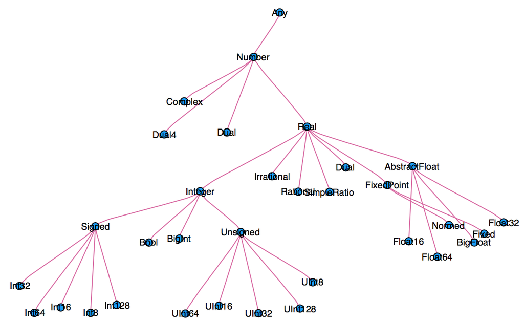

- We can explore type hierarchy with `typeof()`, `supertype()`, and `subtypes()`.

```julia
# 1.0: double precision, 1: 64-bit integer
typeof(1.0), typeof(1)
```

```
(Float64, Int64)
```

```julia
supertype(Float64)
```

```
AbstractFloat
```

```julia
subtypes(AbstractFloat)
```

```
5-element Vector{Any}:
 BigFloat
 Core.BFloat16
 Float16
 Float32
 Float64
```

```julia
# Is Float64 a subtype of AbstractFloat?
Float64 <: AbstractFloat
```

```
true
```

```julia
# On 64bit machine, Int == Int64
Int == Int64
```

```
true
```

```julia
# convert to Float64
convert(Float64, 1)
```

```
1.0
```

```julia
# same as casting
Float64(1)
```

```
1.0
```

```julia
# Float32 vector
x = randn(Float32, 5)
```

```
5-element Vector{Float32}:
  0.75787747
  0.51667124
 -1.8232445
  6.82108f-5
  1.9995484
```

```julia
# convert to Float64
convert(Vector{Float64}, x)
```

```
5-element Vector{Float64}:
  0.7578774690628052
  0.5166712403297424
 -1.8232444524765015
  6.821080023655668e-5
  1.9995484352111816
```

```julia
# same as broadcasting (dot operatation)
Float64.(x)
```

```
5-element Vector{Float64}:
  0.7578774690628052
  0.5166712403297424
 -1.8232444524765015
  6.821080023655668e-5
  1.9995484352111816
```

```julia
# convert Float64 to Int64
convert(Int, 1.0)
```

```
1
```

```julia
convert(Int, 1.5) # should use round(1.5)
```

```
LoadError: InexactError: Int64(1.5)
InexactError: Int64(1.5)

Stacktrace:
 [1] Int64
   @ ./float.jl:994 [inlined]
 [2] convert(::Type{Int64}, x::Float64)
   @ Base ./number.jl:7
 [3] top-level scope
   @ In[105]:1
```

```julia
round(Int, 1.5)
```

```
2
```

## 13 Multiple dispatch

- Multiple dispatch lies in the core of Julia design. It allows built-in and user-defined functions to be overloaded for different combinations of argument types.
- Let’s consider a simple “doubling” function:

```julia
g(x) = x + x
```

```
g (generic function with 1 method)
```

```julia
g(1.5)
```

```
3.0
```

This definition is too broad, since some things, e.g., strings, can’t be added

```julia
g("hello world")
```

```
MethodError: no method matching +(::String, ::String)
The function `+` exists, but no method is defined for this combination of argument types.
String concatenation is performed with * (See also: https://docs.julialang.org/en/v1/manual/strings/#man-concatenation).

Closest candidates are:
  +(::Any, ::Any, ::Any, ::Any...)
   @ Base operators.jl:596
  +(::Bool, ::Complex{Bool})
   @ Base complex.jl:308
  +(::Bool, ::Bool)
   @ Base bool.jl:166
  ...


Stacktrace:
 [1] g(x::String)
   @ Main ./In[107]:1
 [2] top-level scope
   @ In[110]:1
```

- This definition is correct but too restrictive, since any `Number` can be added.

```julia
g(x::Float64) = x + x
```

```
g (generic function with 2 methods)
```

- This definition will automatically work on the entire type tree above!

```julia
g(x::Number) = x + x
```

```
g (generic function with 3 methods)
```

This is a lot nicer than

```julia
function g(x)
    if isa(x, Number)
        return x + x
    else
        throw(ArgumentError("x should be a number"))
    end
end
```

- `methods(func)` function display all methods defined for `func`.

```julia
methods(g)
```

# 3 methods for generic function **g** from Main:

- g(x::**Float64**) in Main at In[111]:1

- g(x::**Number**) in Main at In[112]:1

- g(x) in Main at In[107]:1

- When calling a function with multiple definitions, Julia will search from the narrowest signature to the broadest signature.
- `@which func(x)` marco tells which method is being used for argument signature `x`.

```julia
# an Int64 input
@which g(1)
```

g(x::**Number**) in Main at In[112]:1

```julia
# a Vector{Float64} input
@which g(randn(5))
```

g(x) in Main at In[107]:1

## 14 Just-in-time compilation (JIT)

Following figures are taken from Arch D. Robinson’s slides [Introduction to Writing High Performance Julia](https://www.youtube.com/watch?v=szE4txAD8mk).

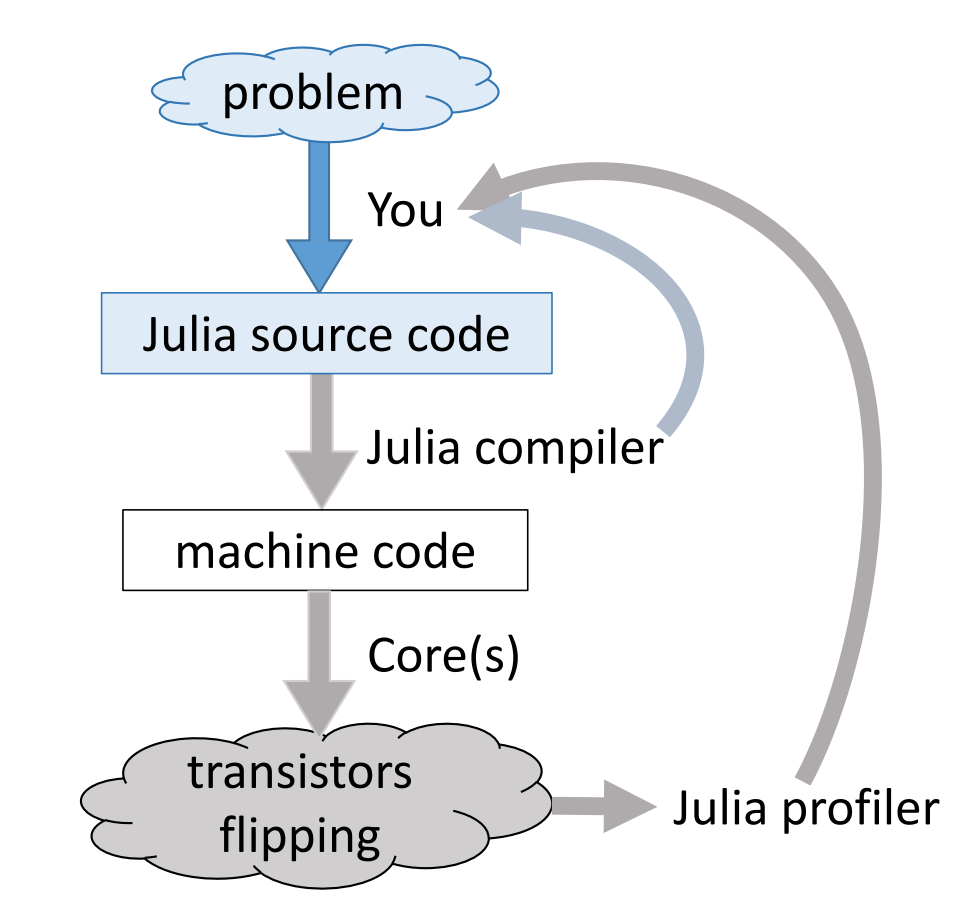

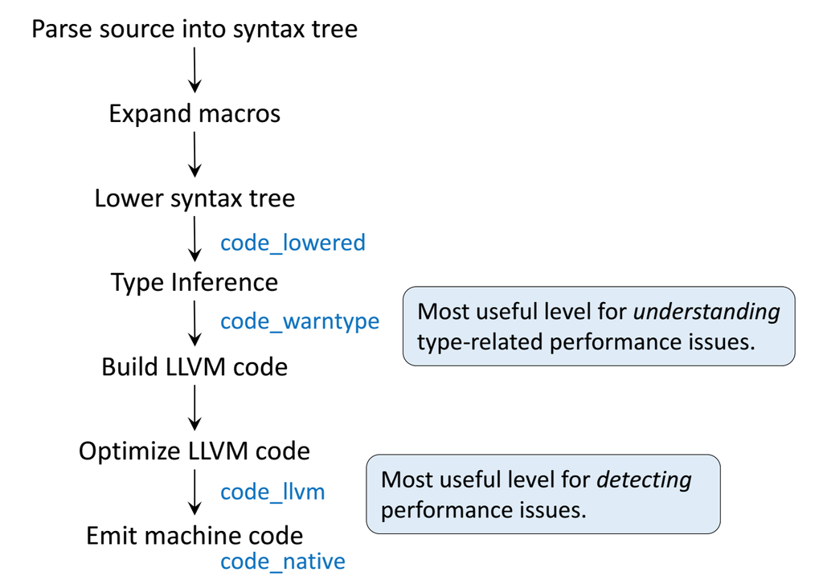

- `Julia`’s efficiency results from its capability to infer the types of **all** variables within a function and then call LLVM compiler to generate optimized machine code at run-time.

Consider the `g` (doubling) function defined earlier. This function will work on **any** type which has a method for `+`.

```julia
g(2), g(2.0)
```

```
(4, 4.0)
```

**Step 1**: Parse Julia code into [abstract syntax tree (AST)](https://en.wikipedia.org/wiki/Abstract_syntax_tree).

```julia
@code_lowered g(2)
```

```
CodeInfo(
1 ─ %1 = x + x
└──      return %1
)
```

**Step 2**: Type inference according to input type.

```julia
# type inference for integer input
@code_warntype g(2)
```

```
MethodInstance for g(::Int64)
  from g(x::Number) @ Main In[112]:1
Arguments
  #self#::Core.Const(Main.g)
  x::Int64
Body::Int64
1 ─ %1 = (x + x)::Int64
└──      return %1
```

```julia
# type inference for Float64 input
@code_warntype g(2.0)
```

```
MethodInstance for g(::Float64)
  from g(x::Float64) @ Main In[111]:1
Arguments
  #self#::Core.Const(Main.g)
  x::Float64
Body::Float64
1 ─ %1 = (x + x)::Float64
└──      return %1
```

**Step 3**: Compile into **LLVM bitcode** (equivalent of R bytecode generated by the `compiler` package).

```julia
# LLVM bitcode for integer input
@code_llvm g(2)
```

```
; Function Signature: g(Int64)
;  @ In[112]:1 within `g`
define i64 @julia_g_29002(i64 signext %"x::Int64") #0 {
top:
; ┌ @ int.jl:87 within `+`
   %0 = shl i64 %"x::Int64", 1
   ret i64 %0
; └
}
```

```julia
# LLVM bitcode for Float64 input
@code_llvm g(2.0)
```

```
; Function Signature: g(Float64)
;  @ In[111]:1 within `g`
define double @julia_g_29080(double %"x::Float64") #0 {
top:
; ┌ @ float.jl:491 within `+`
   %0 = fadd double %"x::Float64", %"x::Float64"
   ret double %0
; └
}
```

We didn’t provide a type annotation. But different LLVM bitcodes were generated depending on the argument type!

In R or Python, `g(2)` and `g(2.0)` would use the same code for both.

In Julia, `g(2)` and `g(2.0)` dispatches to optimized code for `Int64` and `Float64`, respectively.

For integer input `x`, LLVM compiler is smart enough to know `x + x` is simply shifting `x` by 1 bit, which is faster than addition.

- **Step 4**: Lowest level is the **assembly code**, which is machine dependent.

```julia
# Assembly code for integer input
@code_native g(2)
```

```
    .section    __TEXT,__text,regular,pure_instructions
    .build_version macos, 15, 0
    .globl  _julia_g_29177                  ; -- Begin function julia_g_29177
    .p2align    2
_julia_g_29177:                         ; @julia_g_29177
; Function Signature: g(Int64)
; ┌ @ In[112]:1 within `g`
; %bb.0:                                ; %top
; │ @ In[112] within `g`
    ;DEBUG_VALUE: g:x <- $x0
    ;DEBUG_VALUE: g:x <- $x0
; │ @ In[112]:1 within `g`
; │┌ @ int.jl:87 within `+`
    lsl x0, x0, #1
    ret
; └└
                                        ; -- End function
.subsections_via_symbols
```

```julia
# Assembly code for Float64 input
@code_native g(2.0)
```

```
    .section    __TEXT,__text,regular,pure_instructions
    .build_version macos, 15, 0
    .globl  _julia_g_29270                  ; -- Begin function julia_g_29270
    .p2align    2
_julia_g_29270:                         ; @julia_g_29270
; Function Signature: g(Float64)
; ┌ @ In[111]:1 within `g`
; %bb.0:                                ; %top
; │ @ In[111] within `g`
    ;DEBUG_VALUE: g:x <- $d0
    ;DEBUG_VALUE: g:x <- $d0
; │ @ In[111]:1 within `g`
; │┌ @ float.jl:491 within `+`
    fadd    d0, d0, d0
    ret
; └└
                                        ; -- End function
    .section    __DATA,__const
    .p2align    3, 0x0                          ; @"+Core.Float64#29272"
"l_+Core.Float64#29272":
    .quad   "l_+Core.Float64#29272.jit"

.set "l_+Core.Float64#29272.jit", 4717341744
.subsections_via_symbols
```

## 15 Profiling Julia code

Julia has several built-in tools for profiling. The `@time` marco outputs run time and heap allocation. Note the first call of a function incurs (substantial) compilation time.

```julia
# a function defined earlier
function tally(x::Array)
    s = zero(eltype(x))
    for v in x
        s += v
    end
    s
end

using Random
Random.seed!(257)
a = rand(20_000_000)
@time tally(a) # first run: include compile time
```

```
  0.022503 seconds (3.86 k allocations: 183.422 KiB, 20.28% compilation time)
```

```
1.000097950627383e7
```

```julia
@time tally(a)
```

```
  0.023199 seconds (1 allocation: 16 bytes)
```

```
1.000097950627383e7
```

For more robust benchmarking, the BenchmarkTools.jl package is highly recommended.

```julia
@benchmark tally($a)
```

```
BenchmarkTools.Trial: 304 samples with 1 evaluation per sample.
 Range (min … max):  16.246 ms …  18.138 ms  ┊ GC (min … max): 0.00% … 0.00%
 Time  (median):     16.424 ms               ┊ GC (median):    0.00%
 Time  (mean ± σ):   16.459 ms ± 230.248 μs  ┊ GC (mean ± σ):  0.00% ± 0.00%
   ▄█▂        ▁
  ████▆▄▅▅▄▅▄▇█▇▇▄▅▄▆▄▆█▆▆▅▄▅▂▄▂▃▄▄▂▃▁▃▂▃▂▁▁▂▁▁▁▁▂▁▂▁▂▁▁▂▁▁▂▂▂ ▃
  16.2 ms         Histogram: frequency by time         17.1 ms <
 Memory estimate: 0 bytes, allocs estimate: 0.
```

The `Profile` module gives line by line profile results.

```julia
Profile.clear()
@profile tally(a)
Profile.print(format=:flat)
```

```
 Count  Overhead File                 Line Function
 =====  ======== ====                 ==== ========
    16         0 In[124]                 6 tally(x::Vector{Float…
    16         0 @Base/array.jl        902 iterate
    16        16 @Base/essentials.jl   917 getindex
Total snapshots: 228. Utilization: 42% across all threads and tasks. Use the `groupby` kwarg to break down by thread and/or task.
```

One can use [`ProfileView`](https://github.com/timholy/ProfileView.jl) package for better visualization of profile data:

```julia
using ProfileView

ProfileView.view()
```

```julia
# check type stability
@code_warntype tally(a)
```

```
MethodInstance for tally(::Vector{Float64})
  from tally(x::Array) @ Main In[124]:2
Arguments
  #self#::Core.Const(Main.tally)
  x::Vector{Float64}
Locals
  @_3::Union{Nothing, Tuple{Float64, Int64}}
  s::Float64
  v::Float64
Body::Float64
1 ─ %1  = Main.zero::Core.Const(zero)
│   %2  = Main.eltype::Core.Const(eltype)
│   %3  = (%2)(x)::Core.Const(Float64)
│         (s = (%1)(%3))
│   %5  = x::Vector{Float64}
│         (@_3 = Base.iterate(%5))
│   %7  = @_3::Union{Nothing, Tuple{Float64, Int64}}
│   %8  = (%7 === nothing)::Bool
│   %9  = Base.not_int(%8)::Bool
└──       goto #4 if not %9
2 ┄ %11 = @_3::Tuple{Float64, Int64}
│         (v = Core.getfield(%11, 1))
│   %13 = Core.getfield(%11, 2)::Int64
│   %14 = s::Float64
│   %15 = v::Float64
│         (s = %14 + %15)
│         (@_3 = Base.iterate(%5, %13))
│   %18 = @_3::Union{Nothing, Tuple{Float64, Int64}}
│   %19 = (%18 === nothing)::Bool
│   %20 = Base.not_int(%19)::Bool
└──       goto #4 if not %20
3 ─       goto #2
4 ┄ %23 = s::Float64
└──       return %23
```

```julia
# check LLVM bitcode
@code_llvm tally(a)
```

```
; Function Signature: tally(Array{Float64, 1})
;  @ In[124]:2 within `tally`
define double @julia_tally_32859(ptr noundef nonnull align 8 dereferenceable(24) %"x::Array") #0 {
top:
;  @ In[124]:4 within `tally`
; ┌ @ array.jl:902 within `iterate` @ array.jl:902
; │┌ @ essentials.jl:11 within `length`
    %0 = getelementptr inbounds i8, ptr %"x::Array", i64 16
    %.size.sroa.0.0.copyload = load i64, ptr %0, align 8
; │└
; │┌ @ int.jl:513 within `<`
    %.not.not = icmp eq i64 %.size.sroa.0.0.copyload, 0
; │└
   br i1 %.not.not, label %L75, label %L34

L34:                                              ; preds = %top
; │┌ @ essentials.jl:917 within `getindex`
    %1 = load ptr, ptr %"x::Array", align 8
    %2 = load double, ptr %1, align 8
; └└
;  @ In[124]:5 within `tally`
; ┌ @ float.jl:491 within `+`
   %3 = fadd double %2, 0.000000e+00
; └
;  @ In[124]:6 within `tally`
; ┌ @ array.jl:902 within `iterate`
; │┌ @ int.jl:513 within `<`
    %.not.not5358.not = icmp eq i64 %.size.sroa.0.0.copyload, 1
; │└
   br i1 %.not.not5358.not, label %L75, label %L69.preheader

L69.preheader:                                    ; preds = %L34
   %4 = add i64 %.size.sroa.0.0.copyload, -1
   %min.iters.check = icmp ult i64 %.size.sroa.0.0.copyload, 5
   br i1 %min.iters.check, label %scalar.ph, label %vector.ph

vector.ph:                                        ; preds = %L69.preheader
   %n.vec = and i64 %4, -4
   %ind.end = or i64 %n.vec, 1
   %ind.end61 = or i64 %n.vec, 2
```

[output cut: 49 more lines]

```
   %26 = fadd double %24, %22
; └
;  @ In[124]:6 within `tally`
; ┌ @ array.jl:902 within `iterate`
; │┌ @ int.jl:513 within `<`
    %exitcond.not = icmp eq i64 %value_phi1659, %.size.sroa.0.0.copyload
; │└
   br i1 %exitcond.not, label %L75, label %L69

L75:                                              ; preds = %L69, %middle.block, %L34, %top
   %value_phi45 = phi double [ 0.000000e+00, %top ], [ %3, %L34 ], [ %19, %middle.block ], [ %26, %L69 ]
; └
;  @ In[124]:7 within `tally`
  ret double %value_phi45
}
```

```julia
@code_native tally(a)
```

```
    .section    __TEXT,__text,regular,pure_instructions
    .build_version macos, 15, 0
    .globl  _julia_tally_32875              ; -- Begin function julia_tally_32875
    .p2align    2
_julia_tally_32875:                     ; @julia_tally_32875
; Function Signature: tally(Array{Float64, 1})
; ┌ @ In[124]:2 within `tally`
; %bb.0:                                ; %top
; │ @ In[124] within `tally`
    ;DEBUG_VALUE: tally:x <- [DW_OP_deref] $x0
    ;DEBUG_VALUE: tally:x <- [DW_OP_deref] 0
; │ @ In[124]:4 within `tally`
; │┌ @ array.jl:902 within `iterate` @ array.jl:902
; ││┌ @ essentials.jl:11 within `length`
    ldr x10, [x0, #16]
; ││└
    cbz x10, LBB0_4
; %bb.1:                                ; %L34
; ││┌ @ essentials.jl:917 within `getindex`
    ldr x8, [x0]
    ldr d0, [x8]
    movi    d1, #0000000000000000
; │└└
; │ @ In[124]:5 within `tally`
; │┌ @ float.jl:491 within `+`
    fadd    d0, d0, d1
; │└
; │ @ In[124]:6 within `tally`
; │┌ @ array.jl:902 within `iterate`
    subs    x12, x10, #1
    b.eq    LBB0_10
; %bb.2:                                ; %L69.preheader
    cmp x10, #5
    b.hs    LBB0_5
; %bb.3:
    mov w9, #2
    mov w11, #1
    b   LBB0_8
LBB0_4:
    movi    d0, #0000000000000000
```

[output cut: 47 more lines]

```
; ││└
    b.ne    LBB0_9
LBB0_10:                                ; %L75
; │└
; │ @ In[124]:7 within `tally`
    ret
; └
                                        ; -- End function
    .section    __DATA,__const
    .p2align    3, 0x0                          ; @"+Core.Float64#32877"
"l_+Core.Float64#32877":
    .quad   "l_+Core.Float64#32877.jit"

.set "l_+Core.Float64#32877.jit", 4717341744
.subsections_via_symbols
```

**Exercise:** Annotate the loop in `tally` function by `@turbo` from the `LoopVectorization.jl` package and look for the difference in LLVM bitcode and machine code.

## 16 Memory profiling

Detailed memory profiling requires a detour. First let’s write a script `bar.jl`, which contains the workload function `tally` and a wrapper for profiling.

```julia
# run shell command
run(`cat bar.jl`)
```

```
using Profile

function tally(x::Array)
    s = zero(eltype(x))
    for v in x
        s += v
    end
    s
end

# call workload from wrapper to avoid misattribution bug
function wrapper()
    y = rand(10000)
    # force compilation
    println(tally(y))
    # clear allocation counters
    Profile.clear_malloc_data()
    # run compiled workload
    println(tally(y))
end

wrapper()
```

```
Process(`cat bar.jl`, ProcessExited(0))
```

Next, in terminal, we run the script with `--track-allocation=user` option.

```julia
#;julia --track-allocation=user bar.jl
```

The profiler outputs a file `bar.jl.51116.mem`.

```julia
run(`cat bar.jl.51116.mem`)
```

```
        - using Profile
        -
        - function tally(x::Array)
        -     s = zero(eltype(x))
        -     for v in x
        -         s += v
        -     end
        -     s
        - end
        -
        - # call workload from wrapper to avoid misattribution bug
        - function wrapper()
        0     y = rand(10000)
        -     # force compilation
        0     println(tally(y))
        -     # clear allocation counters
        0     Profile.clear_malloc_data()
        -     # run compiled workload
      528     println(tally(y))
        - end
        -
        - wrapper()
        -
```

```
Process(`cat bar.jl.51116.mem`, ProcessExited(0))
```